# STAT3888 — Phase 4: EDA

Gordon | PUFA:SFA ratio, elevated cholesterol, and omega-3 composition

Gordon

2026-10-17

# 1 Exploratory Data Analysis

# 2 1. Definition of elevated or abnormal blood lipids

For this exploratory analysis, use the binary outcomes inherited from Phase 2:

- Elevated total cholesterol: `total_chol_elevated`.
- Elevated LDL cholesterol: `ldl_chol_elevated`.

The ABS biomedical source provides **ranged laboratory categories**, which Phase 2 converted to binary values. These summaries describe high-cholesterol *prevalence*, not mean cholesterol concentrations. Low HDL and high triglycerides are not reconstructed in this Gordon Phase 4 dataset.

# 3 2. Group sizes and ratio distribution

```r
sizes <- d[,.(N=.N, ratio_median=median(pufa_sfa_ratio,na.rm=TRUE),
              PUFA_g_mean=mean(polyunsaturated_fat_g_day1,na.rm=TRUE),
              SFA_g_mean=mean(saturated_fat_g_day1,na.rm=TRUE)),
           by=pufa_sfa_group][order(pufa_sfa_group)]
format_table(sizes,'PUFA:SFA groups and intake characteristics')
```

PUFA:SFA groups and intake characteristics

| pufa_sfa_group | N | ratio_median | PUFA_g_mean | SFA_g_mean |
| --- | --- | --- | --- | --- |
| Low: <0.45 | 1341 | 0.2809 | 9.454 | 35.307 |
| Other ratios | 851 | 0.6270 | 15.658 | 23.023 |
| High: 1.0-1.5 | 130 | 1.1697 | 19.427 | 16.386 |

```r
save_table(sizes,'r_11_ratio_groups.csv')
```

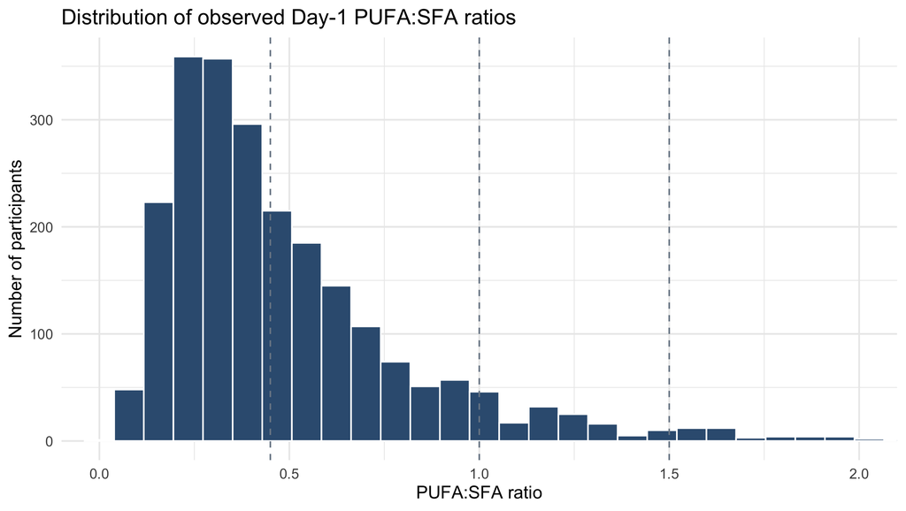

Day-1 PUFA:SFA distribution, restricted to the existing fasting biomedical cohort

```r
p_ratio <- ggplot(d[is.finite(pufa_sfa_ratio)],aes(x=pufa_sfa_ratio))+
  geom_histogram(bins=40,fill='#365C80',color='white')+
  geom_vline(xintercept=c(0.45,1.0,1.5), linetype='dashed',color='#7A8795')+
  coord_cartesian(xlim=c(0,2.0))+
  labs(x='PUFA:SFA ratio',y='Number of participants',
       title='Distribution of observed Day-1 PUFA:SFA ratios')+
  theme_minimal(base_size=12)
print(p_ratio)
```

```r
save_figure(p_ratio,'r_11_ratio_distribution.png')
```

# 4 3. Abnormal lipid prevalence across PUFA:SFA groups

For each group, compute the number of participants with observed outcome measurements, number of abnormal outcomes, ordinary percent and the biomedical survey-weighted percent. The unweighted and weighted figures answer different questions; they are not interchangeable.

```r
eda <- rbindlist(lapply(c('total_chol_elevated','ldl_chol_elevated'),function(oc){
  d[!is.na(get(oc)),.(N=.N,Abnormal_N=sum(get(oc)==1),
    Raw_percent=100*mean(get(oc)),
    Weighted_percent=100*wmean(get(oc),biomedical_weight)),by=pufa_sfa_group][,
    Outcome:=ifelse(oc=='total_chol_elevated','Elevated total cholesterol','Elevated LDL')]
}))
setcolorder(eda,c('Outcome','pufa_sfa_group','N','Abnormal_N','Raw_percent','Weighted_percent'))
setorder(eda,Outcome,pufa_sfa_group)
format_table(eda,'Descriptive prevalence: raw and biomedical-weighted')
```

Descriptive prevalence: raw and biomedical-weighted

| Outcome | pufa_sfa_group | N | Abnormal_N | Raw_percent | Weighted_percent |
| --- | --- | --- | --- | --- | --- |
| Elevated LDL | Low: <0.45 | 1325 | 498 | 37.585 | 35.194 |
| Elevated LDL | Other ratios | 839 | 303 | 36.114 | 33.724 |
| Elevated LDL | High: 1.0-1.5 | 127 | 49 | 38.583 | 28.458 |
| Elevated total cholesterol | Low: <0.45 | 1341 | 509 | 37.957 | 34.047 |
| Elevated total cholesterol | Other ratios | 850 | 310 | 36.471 | 33.288 |
| Elevated total cholesterol | High: 1.0-1.5 | 130 | 53 | 40.769 | 30.961 |

```r
save_table(eda,'r_12_eda_prevalence.csv')
```

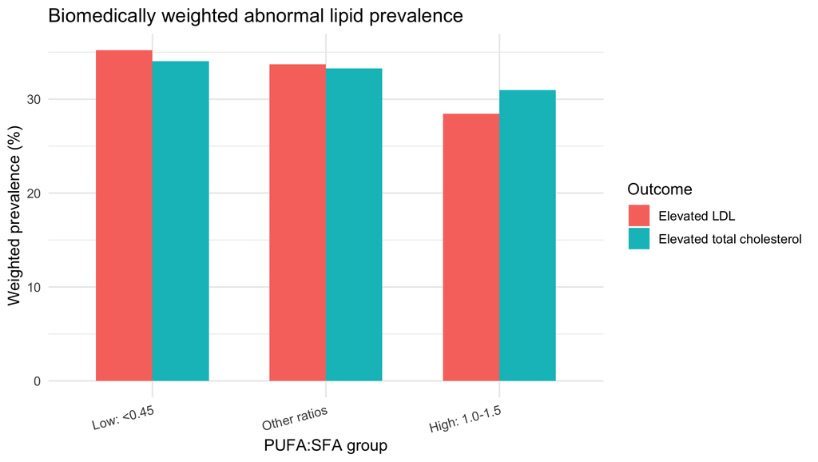

Design-weighted descriptive prevalence. These bars do not show statistical significance or causal effects.

```r
p_prev <- ggplot(eda,aes(x=pufa_sfa_group,y=Weighted_percent,fill=Outcome))+
  geom_col(position='dodge',width=.65)+
  labs(title='Biomedically weighted abnormal lipid prevalence',x='PUFA:SFA group',
       y='Weighted prevalence (%)',fill='Outcome')+
  theme_minimal(base_size=12)+theme(axis.text.x=element_text(angle=15,hjust=1))
print(p_prev)
```

```r
save_figure(p_prev,'r_12_weighted_prevalence.png')
```

# 5 4. Omega-3 and dietary composition

The previously constructed `omega3_proxy_pct_pufa` is a **Day-1 omega-3 proxy as a proportion of total PUFA**; it is not a biomarker or a validated long-term omega-3 consumption measure. This quantity is mechanically linked to the PUFA denominator and should not be interpreted as an isolated omega-3 substitution effect.

```r
comp <- d[,.(N=.N,
    Omega3_proxy_share_mean=mean(omega3_proxy_pct_pufa,na.rm=TRUE),
    Omega3_proxy_share_median=median(omega3_proxy_pct_pufa,na.rm=TRUE),
    Linoleic_share_mean=mean(linoleic_pct_pufa,na.rm=TRUE),
    Energy_kJ_mean=mean(energy_kj_day1,na.rm=TRUE)),by=pufa_sfa_group][order(pufa_sfa_group)]
format_table(comp,'Exploratory within-PUFA composition by observed ratio group')
```

Exploratory within-PUFA composition by observed ratio group

| pufa_sfa_group | N | Omega3_proxy_share_mean | Omega3_proxy_share_median | Linoleic_share_mean | Energy_kJ_mean |
| --- | --- | --- | --- | --- | --- |
| Low: <0.45 | 1341 | 16.018 | 14.613 | 80.758 | 9389.1 |
| Other ratios | 851 | 16.555 | 14.285 | 81.564 | 8746.1 |
| High: 1.0-1.5 | 130 | 15.873 | 13.074 | 82.670 | 8557.3 |

```r
save_table(comp,'r_13_omega3_composition.csv')
```

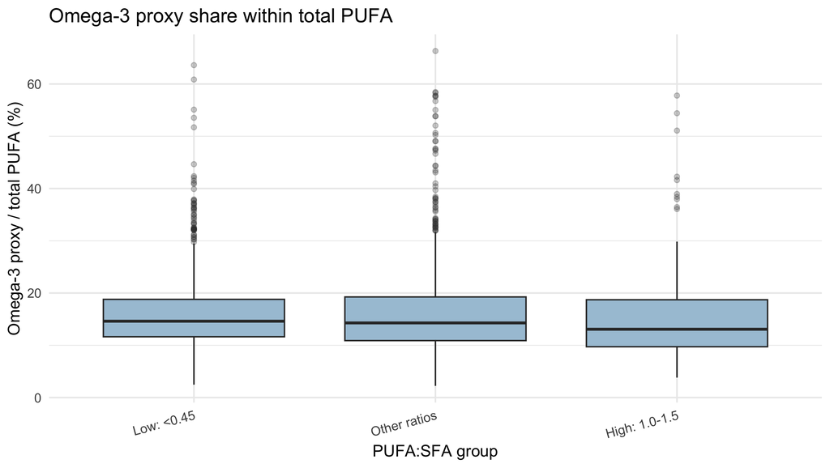

Observed omega-3 proxy share across high, low and intermediate PUFA:SFA groups

```r
p_omega <- ggplot(d[is.finite(omega3_proxy_pct_pufa)],
    aes(x=pufa_sfa_group,y=omega3_proxy_pct_pufa))+
  geom_boxplot(fill='#A8C5D8',outlier.alpha=.25)+
  labs(title='Omega-3 proxy share within total PUFA',
       x='PUFA:SFA group',y='Omega-3 proxy / total PUFA (%)')+
  theme_minimal(base_size=12)+theme(axis.text.x=element_text(angle=15,hjust=1))
print(p_omega)
```

```r
save_figure(p_omega,'r_13_omega3_share.png')
```

# 6 5. Initial findings

1. The high-ratio category is substantially smaller than the low category. This imbalance is especially important in subsequent propensity-based estimation.
2. Raw percentages and survey-weighted prevalence can differ. For instance, the sample’s observed dietary groups are not equally representative of Australia’s biomedical population.
3. An elevated LDL or total cholesterol indicator is a **cross-sectional outcome**. These figures cannot establish how cholesterol would change if an individual altered their diet.
4. Differences across dietary groups must be interpreted in the light of age, sex, location and socioeconomic factors, plus remaining confounding and diet measurement error.
5. The next phase should compare standardised and propensity-adjusted contrasts with uncertainty intervals and sensitivity checks.

# 7 6. Suggested next steps

- Retain the continuous ratio and all three groups for EDA; use only high and low for the proposal-defined binary comparison.
- Include weighting and uncertainty in the causal-methods report.
- Examine omega-3 contribution only as an exploratory composition or interaction analysis and avoid nutrient-causality claims.